# Validation v2: fixated (with new parameters) vs. analyzeeyedry on C1L1.asc

Auto-generated validation report

2026-04-09

# 1. Introduction

This document documents the impact of the changes introduced in the `fixated` package to bring it closer to the **analyzeeyedry** / eyedry convention:

1. **`shorttime` parameter** – fixations ≤ shorttime ms are excluded from FFD/GD/GPT (but TVT still sums all fixations).
2. **Fixed GD first-pass scan** – short fixations outside the word no longer terminate the first-pass scan (they are skipped instead).
3. **`longtime` parameter** – a fixation > longtime on a word causes its FFD/GD/GPT/`sp` to be set to `NA`.
4. **`ttcutoff` parameter** – TVT is set to `NA` when cumulative time exceeds the cutoff.
5. **`truncate_at_display_on` parameter** – straddling fixations are truncated instead of excluded.
6. **New regression measures** – `oreg`, `ireg`, `pfix`, `nfix`, `sp` are now computed.

The comparison is run on `C1L1.asc`, the same UMass EyeTrack file used in `c1l1_comparison.Rmd`.

# 2. Setup

```r
pkg_root          <- file.path(getwd(), "..")
analyzeeyedry_dir <- file.path(getwd(), "analyzeeyedry")

if (!requireNamespace("analyzeeyedry", quietly = TRUE)) {
  install.packages(analyzeeyedry_dir, repos = NULL, type = "source")
}
if (!requireNamespace("fixated", quietly = TRUE)) {
  install.packages(pkg_root, repos = NULL, type = "source")
}

library(analyzeeyedry)
library(fixated)
library(dplyr)
library(ggplot2)
library(tidyr)
library(knitr)

ASC_FILE <- file.path(pkg_root, "data_to_incorporate", "C1L1.asc")
stopifnot(file.exists(ASC_FILE))
cat("ASC file:", ASC_FILE, "\n")
```

```
## ASC file: /home/rstudio/projects/fixated/validation/../data_to_incorporate/C1L1.asc
```

# 3. Parse C1L1.asc (shared helper)

The parsing helpers below are identical to those in `c1l1_comparison.Rmd`.

```r
parse_c1l1 <- function(filepath, trial_pattern = "^[A-Za-z]") {
  lines <- readLines(filepath, warn = FALSE)
  trial_list <- list()
  in_trial   <- FALSE
  seq_n      <- 0L
  cond <- NA_integer_; item <- NA_integer_; tid <- ""
  prefix <- ""; synctime <- NA_real_
  chars_list <- list(); fix_list <- list()

  for (line in lines) {
    if (grepl("MSG\\s.*TRIALID\\s+(\\S+)", line)) {
      m_tid <- regmatches(line, regexpr("TRIALID\\s+(\\S+)", line))
      if (length(m_tid) > 0L) {
        trial_id <- sub("TRIALID\\s+", "", m_tid)
        if (grepl(trial_pattern, trial_id)) {
          m <- regmatches(trial_id, regexpr("^([A-Za-z]+)(\\d+)[A-Za-z](\\d+)", trial_id))
          if (length(m) > 0L) {
            nums <- regmatches(m, gregexpr("\\d+", m))[[1L]]
            pfx  <- regmatches(m, gregexpr("[A-Za-z]+", m))[[1L]][1L]
            if (length(nums) >= 2L) {
              seq_n <- seq_n + 1L; cond <- as.integer(nums[1L])
              item  <- as.integer(nums[2L]); tid <- trial_id; prefix <- pfx
              synctime <- NA_real_; chars_list <- list(); fix_list <- list()
              in_trial <- TRUE
            }
          }
        } else { in_trial <- FALSE }
      }
      next
    }
    if (!in_trial) next
    if (grepl("REGION CHAR", line)) {
      parts <- strsplit(trimws(line), "\\s+")[[1L]]
      np    <- length(parts)
      if (np >= 10L) {
        idx <- as.integer(parts[5L])
        ch  <- if (np >= 11L) parts[7L] else " "
        x_l <- as.numeric(parts[np - 3L]); y_t <- as.numeric(parts[np - 2L])
        x_r <- as.numeric(parts[np - 1L]); y_b <- as.numeric(parts[np])
        chars_list[[length(chars_list) + 1L]] <-
          data.frame(idx = idx, char = ch,
                     x_left = x_l, y_top = y_t, x_right = x_r, y_bottom = y_b,
                     stringsAsFactors = FALSE)
      }
      next
    }
    if (grepl("SYNCTIME", line)) {
      parts <- strsplit(trimws(line), "\\s+")[[1L]]
      if (length(parts) >= 2L) synctime <- as.numeric(parts[2L])
      next
    }
    if (grepl("^EFIX\\s+R", line)) {
      parts <- strsplit(trimws(line), "\\s+")[[1L]]
      if (length(parts) >= 7L) {
        fix_list[[length(fix_list) + 1L]] <- data.frame(
          t_start = as.numeric(parts[3L]), t_end = as.numeric(parts[4L]),
          duration = as.numeric(parts[5L]),
          x = as.numeric(parts[6L]), y = as.numeric(parts[7L]),
          stringsAsFactors = FALSE)
      }
      next
    }
    if (grepl("TRIAL_RESULT", line)) {
      if (in_trial && length(chars_list) > 0L) {
        chars_df <- do.call(rbind, chars_list)
        chars_df <- chars_df[order(chars_df$idx), ]
        fix_df   <- if (length(fix_list) > 0L) do.call(rbind, fix_list) else
          data.frame(t_start = numeric(), t_end = numeric(),
                     duration = numeric(), x = numeric(), y = numeric())
        trial_list[[length(trial_list) + 1L]] <- list(
          trial_id = tid, prefix = prefix, cond = cond, item = item,
          seq = seq_n, synctime = synctime,
          chars = chars_df, fixations = fix_df)
      }
      in_trial <- FALSE; next
    }
  }
  trial_list
}

build_word_rois <- function(chars_df) {
  n <- nrow(chars_df)
  if (n == 0L) return(data.frame())
  word_start_char_idx <- integer(0)
  for (ci in seq_len(n)) {
    if (ci == 1L) {
      word_start_char_idx <- c(word_start_char_idx, ci)
    } else if (chars_df$char[ci - 1L] == " " && chars_df$char[ci] != " ") {
      word_start_char_idx <- c(word_start_char_idx, ci)
    }
  }
  nw <- length(word_start_char_idx)
  if (nw == 0L) return(data.frame())
  word_end_char_idx <- c(word_start_char_idx[-1L] - 1L, n)
  rois <- vector("list", nw)
  for (w in seq_len(nw)) {
    rows   <- word_start_char_idx[w]:word_end_char_idx[w]
    x_s    <- chars_df$x_left[word_start_char_idx[w]]
    x_e    <- chars_df$x_right[word_end_char_idx[w]]
    y_s    <- min(chars_df$y_top[rows])
    y_e    <- max(chars_df$y_bottom[rows])
    word_str <- paste(chars_df$char[word_start_char_idx[w]:
                                      word_end_char_idx[w]], collapse = "")
    rois[[w]] <- data.frame(
      word_id = w, word = word_str,
      x_start = x_s, x_end = x_e, y_start = y_s, y_end = y_e,
      char_start_idx = chars_df$idx[word_start_char_idx[w]],
      char_end_idx   = chars_df$idx[word_end_char_idx[w]],
      stringsAsFactors = FALSE)
  }
  do.call(rbind, rois)
}

trial_list <- parse_c1l1(ASC_FILE)
for (ti in seq_along(trial_list)) {
  trial_list[[ti]]$word_rois <- build_word_rois(trial_list[[ti]]$chars)
}
cat(sprintf("Parsed %d trials\n", length(trial_list)))
```

```
## Parsed 175 trials
```

# 4. analyzeeyedry reference analysis

```r
word_regions_edry <- asc_to_cnt(
  ASC_FILE, trial_pattern = "^[A-Za-z]",
  spillover_gap = 1L, spillover_size = 20L)
fix_edry   <- asc_to_fixations(ASC_FILE, subj = 1L, trial_pattern = "^[A-Za-z]")
fix_edry_r <- assign_regions_to_fixations(fix_edry, word_regions_edry)
nregmax_val <- max(word_regions_edry$nreg, na.rm = TRUE)

measures_edry <- compute_fixation_measures(
  fix_edry_r, word_regions_edry,
  shorttime = 80L, longtime = 800L, nregmax = nregmax_val)
cat(sprintf("analyzeeyedry: measures for %d trials\n", nrow(measures_edry)))
```

```
## analyzeeyedry: measures for 175 trials
```

# 5. fixated analysis (v2 — with new parameters)

Build tidy inputs (SYNCTIME-truncate filter to mirror analyzeeyedry):

```r
build_fixated_inputs <- function(tl, onset_filter = "synctime_truncate") {
  fix_rows <- list(); roi_rows <- list()
  for (ti in seq_along(tl)) {
    tr <- tl[[ti]]
    fix_df <- tr$fixations; rois <- tr$word_rois
    if (nrow(fix_df) == 0L || nrow(rois) == 0L) next
    st_val <- tr$synctime
    if (onset_filter == "synctime_truncate" && !is.na(st_val)) {
      fix_df <- fix_df[fix_df$t_end > st_val, , drop = FALSE]
      straddle <- !is.na(fix_df$t_start) & fix_df$t_start <= st_val
      if (any(straddle)) {
        fix_df$t_start[straddle]  <- st_val
        fix_df$duration[straddle] <- fix_df$t_end[straddle] - st_val
      }
    }
    if (nrow(fix_df) == 0L) next
    for (fi in seq_len(nrow(fix_df))) {
      fix_rows[[length(fix_rows) + 1L]] <- data.frame(
        trial_nr   = ti, cond = tr$cond, item = tr$item,
        start_time = fix_df$t_start[fi], end_time = fix_df$t_end[fi],
        duration   = fix_df$duration[fi],
        avg_x = fix_df$x[fi], avg_y = fix_df$y[fi], stringsAsFactors = FALSE)
    }
    rois$trial_nr <- ti; rois$cond <- tr$cond; rois$item <- tr$item
    roi_rows[[length(roi_rows) + 1L]] <- rois
  }
  list(
    fixations = if (length(fix_rows) > 0L) dplyr::as_tibble(do.call(rbind, fix_rows)) else dplyr::tibble(),
    roi       = if (length(roi_rows) > 0L) dplyr::as_tibble(do.call(rbind, roi_rows)) else dplyr::tibble()
  )
}

inp <- build_fixated_inputs(trial_list, onset_filter = "synctime_truncate")
cat("fixated input:", nrow(inp$fixations), "fixations across",
    dplyr::n_distinct(inp$fixations$trial_nr), "trials\n")
```

```
## fixated input: 2572 fixations across 175 trials
```

Compute measures **without** new parameters (baseline, same as v1):

```r
measures_fix_v1 <- compute_eye_measures(
  inp$fixations, inp$roi, trial_col = "trial_nr")
cat("fixated v1: measures computed\n")
```

```
## fixated v1: measures computed
```

Compute measures **with** new parameters (`shorttime=80`, `longtime=800`, `ttcutoff=4000`):

```r
measures_fix_v2 <- compute_eye_measures(
  inp$fixations, inp$roi, trial_col = "trial_nr",
  shorttime = 80L, longtime = 800L, ttcutoff = 4000L)
cat("fixated v2: measures computed with shorttime=80, longtime=800, ttcutoff=4000\n")
```

```
## fixated v2: measures computed with shorttime=80, longtime=800, ttcutoff=4000
```

# 6. Reshape analyzeeyedry to long format

```r
trial_key <- dplyr::tibble(
  trial_nr = seq_along(trial_list),
  cond     = sapply(trial_list, `[[`, "cond"),
  item     = sapply(trial_list, `[[`, "item"))

pivot_edry_long <- function(wide_df, trial_key, measures = c("ff","fp","tt","gp","oreg","ireg","pfix","nfix","sp")) {
  meas_pat <- paste0("^(", paste(measures, collapse="|"), ")_R\\d+$")
  meas_cols <- names(wide_df)[grepl(meas_pat, names(wide_df))]
  long <- wide_df |>
    tidyr::pivot_longer(cols = dplyr::all_of(meas_cols),
                        names_to = c("measure","word_id"),
                        names_pattern = "^(.+)_R(\\d+)$",
                        values_to = "value") |>
    dplyr::mutate(word_id = as.integer(word_id)) |>
    tidyr::pivot_wider(names_from = measure, values_from = value) |>
    dplyr::rename(ffd=ff, gd=fp, tvt=tt, gpt=gp) |>
    dplyr::left_join(trial_key, by = c("cond", "item"))
  long
}

edry_long <- pivot_edry_long(measures_edry, trial_key)
cat("analyzeeyedry long format:", nrow(edry_long), "rows\n")
```

```
## analyzeeyedry long format: 4025 rows
```

# 7. Merge and compare

```r
compare <- edry_long |>
  dplyr::select(trial_nr, cond, item, word_id,
                ffd_edry=ffd, gd_edry=gd, gpt_edry=gpt, tvt_edry=tvt,
                oreg_edry=oreg, ireg_edry=ireg, pfix_edry=pfix,
                nfix_edry=nfix, sp_edry=sp) |>
  dplyr::inner_join(
    measures_fix_v1 |>
      dplyr::select(trial_nr, word_id,
                    ffd_v1=ffd, gd_v1=gd, gpt_v1=gpt, tvt_v1=tvt),
    by = c("trial_nr","word_id")) |>
  dplyr::inner_join(
    measures_fix_v2 |>
      dplyr::select(trial_nr, word_id,
                    ffd_v2=ffd, gd_v2=gd, gpt_v2=gpt, tvt_v2=tvt,
                    oreg_v2=oreg, ireg_v2=ireg, pfix_v2=pfix,
                    nfix_v2=nfix, sp_v2=sp),
    by = c("trial_nr","word_id")) |>
  dplyr::arrange(trial_nr, word_id)

cat(sprintf("Comparison table: %d rows\n", nrow(compare)))
```

```
## Comparison table: 2037 rows
```

# 8. Impact of new parameters

## 8.1 Helper function

```r
agree_stats <- function(df, edry_col, fix_col) {
  d <- df[[fix_col]] - df[[edry_col]]
  n_both  <- sum(!is.na(df[[edry_col]]) & !is.na(df[[fix_col]]))
  n_agree <- sum(abs(d) < 1, na.rm = TRUE)
  n_only_edry <- sum(!is.na(df[[edry_col]]) & is.na(df[[fix_col]]))
  n_only_fix  <- sum(is.na(df[[edry_col]]) & !is.na(df[[fix_col]]))
  data.frame(
    edry_col    = edry_col,
    fix_col     = fix_col,
    n_both      = n_both,
    n_agree     = n_agree,
    pct_agree   = round(100 * n_agree / max(n_both, 1), 1),
    mean_abs_diff = round(mean(abs(d), na.rm = TRUE), 1),
    n_only_edry = n_only_edry,
    n_only_fix  = n_only_fix
  )
}
```

## 8.2 First Fixation Duration (FFD)

```r
stats_ffd <- dplyr::bind_rows(
  agree_stats(compare, "ffd_edry", "ffd_v1"),
  agree_stats(compare, "ffd_edry", "ffd_v2")
)
knitr::kable(stats_ffd, caption = "FFD: v1 (no filter) vs v2 (shorttime+longtime)")
```

FFD: v1 (no filter) vs v2 (shorttime+longtime)

| edry_col | fix_col | n_both | n_agree | pct_agree | mean_abs_diff | n_only_edry | n_only_fix |
| --- | --- | --- | --- | --- | --- | --- | --- |
| ffd_edry | ffd_v1 | 1183 | 111 | 9.4 | 3.0 | 71 | 18 |
| ffd_edry | ffd_v2 | 1186 | 111 | 9.4 | 0.9 | 68 | 3 |

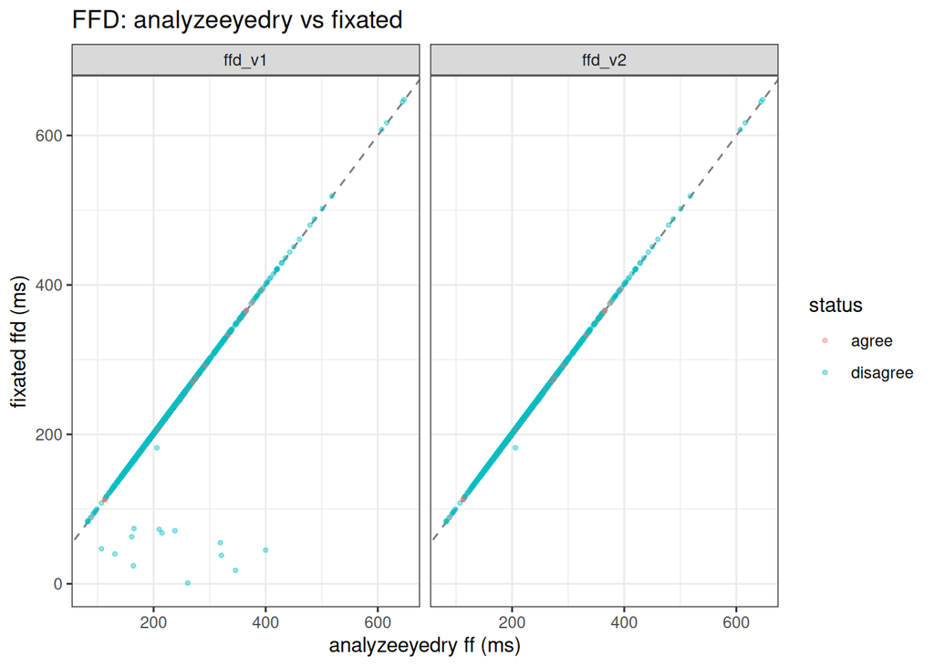

```r
ffd_plot <- compare |>
  dplyr::filter(!is.na(ffd_edry)) |>
  dplyr::select(ffd_edry, ffd_v1, ffd_v2) |>
  tidyr::pivot_longer(cols = c(ffd_v1, ffd_v2), names_to = "version",
                      values_to = "ffd_fix") |>
  dplyr::mutate(diff = ffd_fix - ffd_edry,
                status = ifelse(abs(diff) < 1, "agree", "disagree"))

ggplot(ffd_plot |> dplyr::filter(!is.na(ffd_fix)),
       aes(x = ffd_edry, y = ffd_fix, colour = status)) +
  geom_abline(slope = 1, intercept = 0, linetype = "dashed", colour = "grey50") +
  geom_point(alpha = 0.4, size = 0.8) +
  facet_wrap(~version) +
  labs(title = "FFD: analyzeeyedry vs fixated",
       x = "analyzeeyedry ff (ms)", y = "fixated ffd (ms)") +
  theme_bw()
```

## 8.3 Gaze Duration (GD)

```r
stats_gd <- dplyr::bind_rows(
  agree_stats(compare, "gd_edry", "gd_v1"),
  agree_stats(compare, "gd_edry", "gd_v2")
)
knitr::kable(stats_gd, caption = "GD: v1 vs v2")
```

GD: v1 vs v2

| edry_col | fix_col | n_both | n_agree | pct_agree | mean_abs_diff | n_only_edry | n_only_fix |
| --- | --- | --- | --- | --- | --- | --- | --- |
| gd_edry | gd_v1 | 1182 | 75 | 6.3 | 2.9 | 71 | 19 |
| gd_edry | gd_v2 | 1185 | 75 | 6.3 | 1.4 | 68 | 3 |

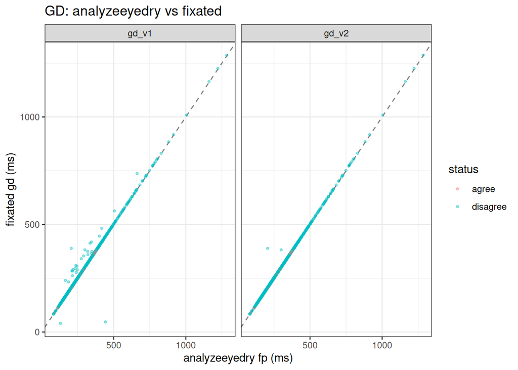

```r
gd_plot <- compare |>
  dplyr::filter(!is.na(gd_edry)) |>
  dplyr::select(gd_edry, gd_v1, gd_v2) |>
  tidyr::pivot_longer(cols = c(gd_v1, gd_v2), names_to = "version",
                      values_to = "gd_fix") |>
  dplyr::mutate(diff = gd_fix - gd_edry,
                status = ifelse(abs(diff) < 1, "agree", "disagree"))

ggplot(gd_plot |> dplyr::filter(!is.na(gd_fix)),
       aes(x = gd_edry, y = gd_fix, colour = status)) +
  geom_abline(slope = 1, intercept = 0, linetype = "dashed", colour = "grey50") +
  geom_point(alpha = 0.4, size = 0.8) +
  facet_wrap(~version) +
  labs(title = "GD: analyzeeyedry vs fixated",
       x = "analyzeeyedry fp (ms)", y = "fixated gd (ms)") +
  theme_bw()
```

## 8.4 Go-Past Time (GPT)

```r
stats_gpt <- dplyr::bind_rows(
  agree_stats(compare, "gpt_edry", "gpt_v1"),
  agree_stats(compare, "gpt_edry", "gpt_v2")
)
knitr::kable(stats_gpt, caption = "GPT: v1 vs v2")
```

GPT: v1 vs v2

| edry_col | fix_col | n_both | n_agree | pct_agree | mean_abs_diff | n_only_edry | n_only_fix |
| --- | --- | --- | --- | --- | --- | --- | --- |
| gpt_edry | gpt_v1 | 1245 | 66 | 5.3 | 13.5 | 11 | 299 |
| gpt_edry | gpt_v2 | 1243 | 66 | 5.3 | 8.5 | 13 | 279 |

## 8.5 Total Viewing Time (TVT)

```r
stats_tvt <- dplyr::bind_rows(
  agree_stats(compare, "tvt_edry", "tvt_v1"),
  agree_stats(compare, "tvt_edry", "tvt_v2")
)
knitr::kable(stats_tvt, caption = "TVT: v1 vs v2")
```

TVT: v1 vs v2

| edry_col | fix_col | n_both | n_agree | pct_agree | mean_abs_diff | n_only_edry | n_only_fix |
| --- | --- | --- | --- | --- | --- | --- | --- |
| tvt_edry | tvt_v1 | 1525 | 62 | 4.1 | 6.3 | 11 | 19 |
| tvt_edry | tvt_v2 | 1525 | 62 | 4.1 | 4.5 | 11 | 17 |

## 8.6 All measures summary

```r
stats_all <- dplyr::bind_rows(
  agree_stats(compare, "ffd_edry", "ffd_v1"),
  agree_stats(compare, "ffd_edry", "ffd_v2"),
  agree_stats(compare, "gd_edry",  "gd_v1"),
  agree_stats(compare, "gd_edry",  "gd_v2"),
  agree_stats(compare, "gpt_edry", "gpt_v1"),
  agree_stats(compare, "gpt_edry", "gpt_v2"),
  agree_stats(compare, "tvt_edry", "tvt_v1"),
  agree_stats(compare, "tvt_edry", "tvt_v2")
)
knitr::kable(stats_all,
             caption = "Overall agreement statistics: v1 (no filter) vs v2 (shorttime=80, longtime=800, ttcutoff=4000)")
```

Overall agreement statistics: v1 (no filter) vs v2 (shorttime=80, longtime=800, ttcutoff=4000)

| edry_col | fix_col | n_both | n_agree | pct_agree | mean_abs_diff | n_only_edry | n_only_fix |
| --- | --- | --- | --- | --- | --- | --- | --- |
| ffd_edry | ffd_v1 | 1183 | 111 | 9.4 | 3.0 | 71 | 18 |
| ffd_edry | ffd_v2 | 1186 | 111 | 9.4 | 0.9 | 68 | 3 |
| gd_edry | gd_v1 | 1182 | 75 | 6.3 | 2.9 | 71 | 19 |
| gd_edry | gd_v2 | 1185 | 75 | 6.3 | 1.4 | 68 | 3 |
| gpt_edry | gpt_v1 | 1245 | 66 | 5.3 | 13.5 | 11 | 299 |
| gpt_edry | gpt_v2 | 1243 | 66 | 5.3 | 8.5 | 13 | 279 |
| tvt_edry | tvt_v1 | 1525 | 62 | 4.1 | 6.3 | 11 | 19 |
| tvt_edry | tvt_v2 | 1525 | 62 | 4.1 | 4.5 | 11 | 17 |